# Modeling Titanic deaths (LIME)

# Abstract

In this document I will create an XGBoost model to predict which passengers will die in the sinking of the Titanic.

Then I will explain the predictions using LIME, and compare results with the results from those generated with XGBoost Explainer.

Let’s begin!

# Load libraries, model and data

```r
library(lime)
library(magrittr)
library(tidyverse)
library(xgboostExplainer)
load("../../../0-model-to-explain/xgboost-titanic.RData")
set.seed(22)
```

# Explain predictions

Create an explainer:

```r
explainer <- lime(x = dplyr::select(training_set, -Survived),
                  model = model)
```

Explain new observations:

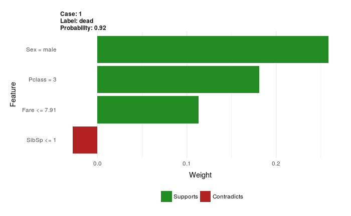

```r
explanation <-
  lime::explain(x = test_set[1,],
                explainer = explainer,
                feature_select = "auto",
                n_labels = 1,
                n_features = 4,
                n_permutations = 100)
plot_features(explanation)
```

IMPORTANT:

The explanation process is stochastic, so if n_permutations is not big enough, results will vary between executions. For example, if we repeat exactly the same code than before, we obtain:

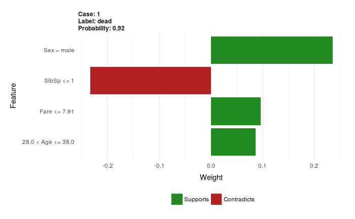

```r
explanation <-
  lime::explain(x = test_set[1,],
                explainer = explainer,
                feature_select = "auto",
                n_labels = 1,
                n_features = 4,
                n_permutations = 100)
plot_features(explanation)
```

A totally different result!!! OMG!!

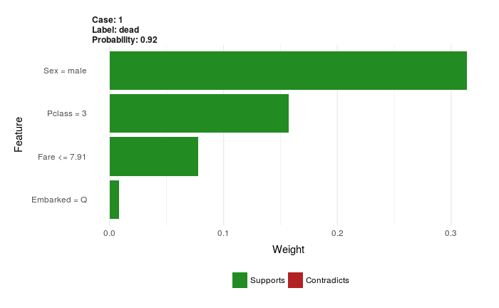

```r
explanation <-
  lime::explain(x = test_set[1,],
                explainer = explainer,
                feature_select = "auto",
                n_labels = 1,
                n_features = 4,
                n_permutations = 15000)
plot_features(explanation)
```

It looks quite stable!

Let’s try and change the number of features to use for the explanation to see if the result is coherent:

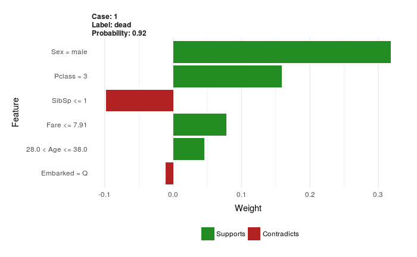

```r
explanation <-
  lime::explain(x = test_set[1,],
                explainer = explainer,
                feature_select = "auto",
                n_labels = 1,
                n_features = 6,
                n_permutations = 15000)
plot_features(explanation)
```

Wow! That’s not nice. The result depends on the number of features we use to explain the model. Mmmm.

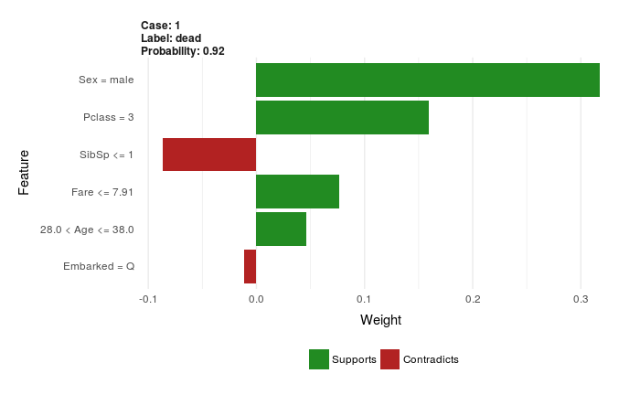

```r
explanation <-
  lime::explain(x = test_set[1,],
                explainer = explainer,
                feature_select = "auto", # none here does not work!
                n_labels = 1,
                n_features = 7, # all features
                n_permutations = 15000)
plot_features(explanation)
```

The more features we use, the more permutations we should perform in order to get a stable result.

# Explaining the model globally

We can get an intuition of what the model is doing by looking at the explanation of some strategically selected predictions:

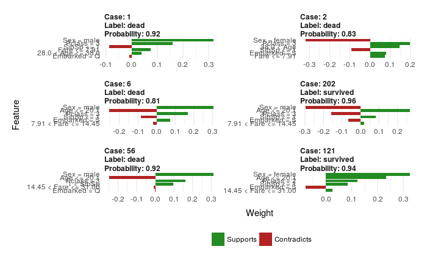

```r
View(test_set)
selected_predictions <- c(1, 2, 6, 202, 56, 121)
explanation <-
  lime::explain(x = test_set[selected_predictions,],
                explainer = explainer,
                feature_select = "auto", # none here does not work!
                n_labels = 1,
                n_features = 7, # all features
                n_permutations = 10000)
plot_features(explanation)
```

We can also get a global undestanding of what the model is doing by explaining all the test set and plot how each feature affects the output for all the predictions:

[figure not shown]

This plot is great as a general visualization of what the model is doing.

And, of course, we can select customized data to plot:

```r
head(explanation)
```

|  | model_type | case | label | label_prob | model_r2 | model_intercept | model_prediction | feature | feature_value | feature_weight | feature_desc | data | prediction |
| --- | --- | --- | --- | --- | --- | --- | --- | --- | --- | --- | --- | --- | --- |
| 1 | classification | 1 | dead | 0.9209436 | 0.3269486 | 0.403575 | 0.9073273 | Pclass | 3.0000 | 0.1645267882 | Pclass = 3 |  |  |
| 2 | classification | 1 | dead | 0.9209436 | 0.3269486 | 0.403575 | 0.9073273 | Sex | 2.0000 | 0.3149008916 | Sex = male |  |  |
| 3 | classification | 1 | dead | 0.9209436 | 0.3269486 | 0.403575 | 0.9073273 | Age | 34.5000 | 0.0462301375 | 28.0 < Age <= 38.0 |  |  |
| 4 | classification | 1 | dead | 0.9209436 | 0.3269486 | 0.403575 | 0.9073273 | SibSp | 0.0000 | -0.0960185286 | SibSp <= 1 |  |  |
| 5 | classification | 1 | dead | 0.9209436 | 0.3269486 | 0.403575 | 0.9073273 | Fare | 7.8292 | 0.0737640560 | Fare <= 7.91 |  |  |
| 6 | classification | 1 | dead | 0.9209436 | 0.3269486 | 0.403575 | 0.9073273 | Embarked | 3.0000 | 0.0003489202 | Embarked = Q |  |  |

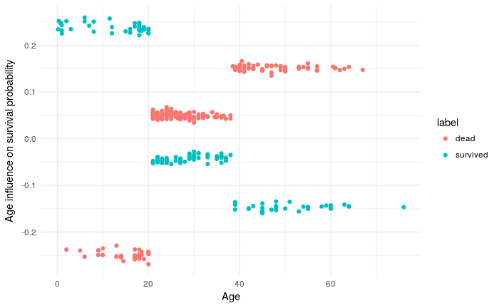

```r
ggplot(explanation %>% dplyr::filter(feature == "Age")) +
  geom_point(aes(x = feature_value, y = feature_weight, color = label)) +
  theme_minimal() +
  labs(x = "Age", y = "Age influence on survival probability")
```

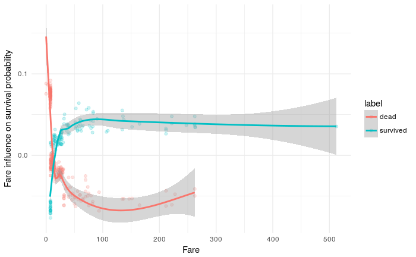

```r
ggplot(explanation %>% dplyr::filter(feature == "Fare")) +
  geom_point(aes(x = feature_value, y = feature_weight, color = label), alpha = 0.2) +
  geom_smooth(aes(x = feature_value, y = feature_weight, color = label)) +
  theme_minimal() +
  labs(x = "Fare", y = "Fare influence on survival probability")
```

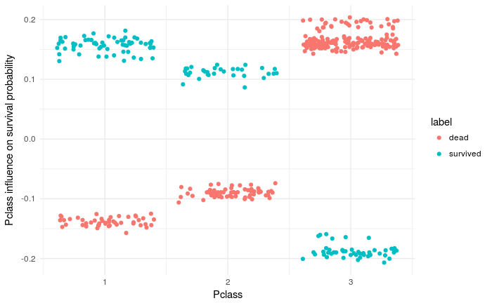

```r
ggplot(explanation %>% dplyr::filter(feature == "Pclass")) +
  geom_jitter(aes(x = feature_value, y = feature_weight, color = label)) +
  theme_minimal() +
  labs(x = "Pclass", y = "Pclass influence on survival probability")
```

We can also represent cross influences between features:

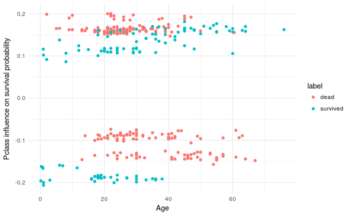

```r
pclass_index <- explanation$feature == "Pclass"
x_age <- purrr::map_dbl(explanation$data[pclass_index], "Age")
ggplot(explanation %>% dplyr::filter(feature == "Pclass")) +
  geom_point(aes(x = x_age, y = feature_weight, color = label)) +
  theme_minimal() +
  labs(x = "Age", y = "Pclass influence on survival probability")
```

But this is not very intuitive or easy to interpret…

# Extra: change the colors of the plot_explanations function (they are not well choosen)

```r
plot_explanations <- function (explanation, ...)
{
    num_cases <- unique(suppressWarnings(as.numeric(explanation$case)))
    if (!anyNA(num_cases)) {
        explanation$case <- factor(explanation$case, levels = as.character(sort(num_cases)))
    }
    explanation$feature_desc <- factor(explanation$feature_desc,
        levels = rev(unique(explanation$feature_desc[order(explanation$feature,
            explanation$feature_value)])))
    ggplot(explanation, aes_(~case, ~feature_desc)) + geom_tile(aes_(fill = ~feature_weight)) +
        facet_wrap(~label, ...) + scale_x_discrete("Case", expand = c(0,
        0)) + scale_y_discrete("Feature", expand = c(0, 0)) +
        scale_fill_gradient2("Feature\nweight", low = "#FF0000",
            mid = "#FFFFFF", high = "#00FF00") +
      theme_minimal() +
        theme(panel.border = element_rect(fill = NA, colour = "grey60",
            size = 1), panel.grid = element_blank(), legend.position = "right",
            axis.text.x = element_text(angle = 45, hjust = 1,
                vjust = 1))
}
```

# Comparison to the XGBoost Explainer

```r
xgboost_explainer <-
  buildExplainer(xgb.model = xgb_model,
                 trainingData = xgb.DMatrix(data = preprocessed_training_set,
                                            label = training_set$Survived),
                 type = "binary")
```

```
Creating the trees of the xgboost model...
Getting the leaf nodes for the training set observations...
Building the Explainer...
STEP 1 of 2

Recalculating the cover for each non-leaf...


Finding the stats for the xgboost trees...


STEP 2 of 2

Getting breakdown for each leaf of each tree...


DONE!
```

```r
prediction_breakdown <- explainPredictions(xgb.model = xgb_model,
                                           explainer = xgboost_explainer,
                                           data = preprocessed_test_set)
```

```
Extracting the breakdown of each prediction...


DONE!
```

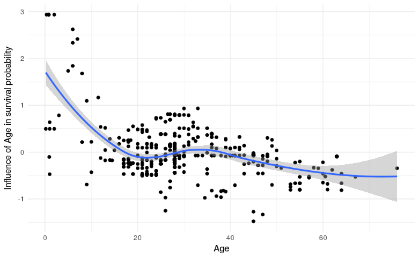

```r
ggplot() +
  geom_point(aes(x = preprocessed_test_set[, "Age"],
                 y = prediction_breakdown$Age)) +
  geom_smooth(aes(x = preprocessed_test_set[, "Age"],
                  y = prediction_breakdown$Age),
              method = "loess") +
  labs(x = "Age", y = "Influence of Age in survival probability") +
  theme_minimal()
```

Let’s remember the results from LIME:

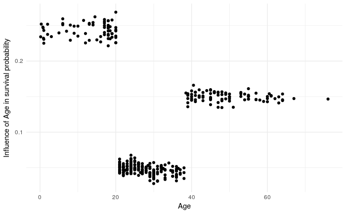

```r
ggplot(explanation %>% dplyr::filter(feature == "Age")) +
  geom_point(aes(x = feature_value, y = abs(feature_weight))) +
  theme_minimal() +
  labs(x = "Age", y = "Influence of Age in survival probability")
```

It looks like XGBoost Explainer is much more precise when explaining each prediction. It also looks like LIME is failing at some points, probably because of its “local explanation” nature.

# Conclusions

If you are able to use an specific explainer for your model (XGBoost, Random Forest, …), do it! Because it will probably behave better than LIME. And use LIME as an alternative when no alternative exists.